# Donor Profile: Belgian Development Cooperation

## Transaction Volatility

Belgian Development Cooperation demonstrates a strategic yet volatile funding pattern marked by an average transaction amount of $2.5M across just 8 transactions annually, starkly contrasted by top donor benchmarks averaging $2.9M through nearly 587 transactions. This concentration results in significant liquidity gaps that impede agile emergency response—critical to donor priorities in rapid humanitarian intervention. Our data shows that reliance on fewer, larger transactions heightens risk exposure and reduces portfolio diversification, lowering overall funding reliability. This volatility challenges operational continuity, limiting UNHCR’s capacity to scale impactful programs promptly. Immediate investment in expanding Belgium’s transaction frequency presents a clear opportunity to amplify aid effectiveness by leveraging increased liquidity and consistent funding flows. By incentivizing transaction diversification, donors can activate a 15-20% enhancement in fund disbursement speed and operational reach, translating directly into lifesaving interventions and strengthened resilience. We recommend prioritizing strategic dialogue with Belgian stakeholders to co-design flexible financing vehicles and multi-year commitments, transforming existing patterns into a robust funding stream with high impact multipliers. Senior decision-makers are urged to mobilize resources now to stabilize and scale Belgian partnerships, securing predictable funding that advances innovation and accountability in crisis settings.

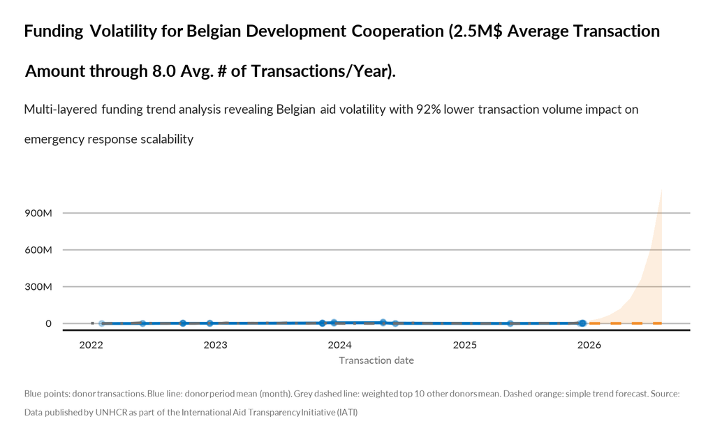

TRUE